# Varroa-virus meta-transcriptomic analysis

Nurit Eliash and Sasha Mikheyev

1/22/2020

In this study we investigated virus-virus and vector-virus interactions by two approaches: (1) meta-transciptomic and (2) gene-silencing experiments.

In the meta-transcriptomic analysis we looked at the overall viral landscape in the different libraries, detected vector modules (co-expressing genes using gene-network analysis), and correlated the viruses’ abundance to the vector modules. Last, we tested if the virus abundance matrix can predict the virus-vector interaction.

## Before we start the analysis

### Sequence Read Archive (SRA) data collection

We searched for the term “varroa” in the SRA databases (NCBI, January 2020) with the following filters: * *Source*: “RNA” * *Library Strategy*: “RNA-seq” (Random sequencing of whole transcriptome) * *Library Source*: “TRANSCRIPTOMIC”, “VIRAL RNA” * We included only whole mites (not partial organs)

### Reads mapping and transcripts quantification

The reads were mapped to both available varroa genome (Vdes_3.0, accession number: GCF_002443255 (Techer et al. 2019)), and to the genomes of 23 selected viruses (table 1). The alignment and estimation of transcript and virus abundances were done using Kallisto (Bray et al. 2016) (version 0.46.1 with default options). The abundances were outputted in transcripts per million (TPM) units.

### Load libraries, data and RNAseq library filtration

Load libraries

```r
library("dplyr")
library("tidyverse")
library("vegan")
library("DESeq2")
library("ggfortify")
library("WGCNA")
options(stringsAsFactors = FALSE) # Allow multi-threading within WGCNA. This helps speed up certain calculations.
library("rmarkdown")
library("knitr") # for the markdown
library("kableExtra") # for creating a scrolling table
library("ggplot2") # for plotting
library("ape") # for mantel.test
library("Biostrings")
library("ggrepel") # for spreading text labels on the plot
library("scales") # for axis labels notation
library("GO.db") # for GO term annotation
library("reshape2")
library("RSQLite")
library("AnnotationDbi") # for GO term annotation
library("GSEABase")
library("GOstats")
library("maps") # for the map background
library("htmltools")
library("rgdal")
library("grid")
library("gridExtra")
library("GeneOverlap") # for making the overlapping genes
library("cluster")
library("rmdformats")
library("corrplot") # for virus-virus correlation
library("viridis")
library("hrbrthemes")
library("ggthemes")
library("RColorBrewer")
library("naniar")
knitr::opts_chunk$set(echo = TRUE)
setwd("/Users/nuriteliash/Documents/GitHub/varroa-virus-networks") #set the directory as the local GitHub local repository
```

### Creat the initial data frame

The mapped libraries were used as input to make a data frame where each column is a SRR library, and each row is an isoform. The cells contain the isoform TPM.  
The output data frame contains 35,669 isoforms of 71 varroa libraries. the first 35,641 rows belong to the varroa genes, and the last 28 rows are reads that matched to varroa/bee viruses.

```r
# First make a function for making the mapped reads (output of kallisto) into a data frame
read_kallisto <- function(filename) {
  sampleName <- sub("data/kallisto/(.*).tsv.gz","\\1", filename)
  return(read_tsv(filename) %>%
           dplyr::select(!!sampleName := tpm))
}

# now make the data frame, which contain all 71 libraries:
df_71 <- list.files(path = "data/kallisto", full.names = TRUE) %>%
  lapply(read_kallisto) %>%
  bind_cols()

# add a column "target_id" with the isoform/virus ID
df_71$target_id <- list.files(path = "data/kallisto", full.names = TRUE)[1] %>%
  read_tsv() %>%
  dplyr::select(target_id) %>%
  pull()

#save(df_71, file = "/Users/nuriteliash/Documents/GitHub/varroa-virus-networks/data/kallisto_71.rds")
```

### Join isoforms into genes

```r
# Next, we join isoforms that belong to the same gene.

# Load the data frame with varroa genes and viruses' genomes
load(file = "/Users/nuriteliash/Documents/GitHub/varroa-virus-networks/data/kallisto_71.rds")

# Import the varroa transcripts ("target_id") and their corresponding gene ("gene_id").
varroa_isoforms <- read_tsv("/Users/nuriteliash/Documents/GitHub/varroa-virus-networks/data/gene2isoform.txt.gz", col_names = c("gene_id", "target_id"))

# Join the varroa transcripts (varroa_isoforms), and the library tpm (df), by the isoform ID ("target_id"). As we do "left_join", the final data frame of "gene_tpm" contain ONLY varroa genes, excluding viruses' tpm.
gene_tpm_71 <-  left_join(varroa_isoforms, df_71, by = "target_id")

# Collapse isoforms ("target_id") to a single row of a gene ("gene_id"), and sum the tpm(s) per gene per library
gene_tpm_collps_71 <- gene_tpm_71 %>%
  gather("library","tpm", -target_id, -gene_id) %>%
  group_by(gene_id, library) %>%
  summarise(gene_tpm_71 = sum(tpm))

# spread the table again, by library
final_gene_tpm_71 <- spread(gene_tpm_collps_71, key = "library", value = "gene_tpm_71") %>% column_to_rownames('gene_id')

# this table will be used for all further analyses
# save(final_gene_tpm_71, file = "/Users/nuriteliash/Documents/GitHub/varroa-virus-networks/results/final_gene_tpm_71.rds")
```

### Detect outlier based on PCA

Next, we perform Principle Component Analysis (PCA) on varroa genes, to detect outlierd libraries

```r
# load the table
load(file = "/Users/nuriteliash/Documents/GitHub/varroa-virus-networks/results/final_gene_tpm_71.rds")

# Before PCA, we transpose the table "final_gene_tpm_71", and transform (log10+0.000001)
final_gene_tpm_71_T<- transposeBigData(log10(final_gene_tpm_71 + 0.000001))

PCA_71 <- prcomp(final_gene_tpm_71_T)
p71 <- autoplot(PCA_71, label = TRUE, x = 1, y = 2)+
  ggtitle("a. PCA of 71 libraries based on gene expression")

# Five libraries are obvious outliers: "SRR5109825", "SRR5109827", "SRR533974" , "SRR3927496", "SRR8867385".
final_gene_tpm_66_T <- final_gene_tpm_71_T %>%
  rownames_to_column("library") %>%
  dplyr::filter(!(library %in% c("SRR5109825", "SRR5109827", "SRR533974" , "SRR3927496", "SRR8867385"))) %>% column_to_rownames("library")
PCA_66 <- prcomp(final_gene_tpm_66_T)
p66 <- autoplot(PCA_66, label = TRUE, x = 1, y = 2)+
  ggtitle("b. PCA of 66 libraries based on gene expression")

# plot the two PCA plots together:
sizeGrWindow(9, 5)
par(mfrow = c(1,2));
cex1 = 0.9;
grid.arrange(p71,p66,nrow = 1, ncol = 2)
# when we remove them and repeat the PCA, the library scatter more homogeneously.
```

After filtering outlier libraries (based on PCA analysis), we used the left 66 SRAs belonging to 9 studies of varroa RNAseq for further analyses (details of the final libraries available in table S5). ### Remove outlier libraries and save data frame of varroa genes to WGCNA

```r
# We remove the five outlier libraries from the data frame, and save for subsequent analyses
load(file = "/Users/nuriteliash/Documents/GitHub/varroa-virus-networks/data/kallisto_71.rds")
df <- df_71 %>% dplyr::select(-c("SRR5109825", "SRR5109827", "SRR533974" , "SRR3927496", "SRR8867385"))

# In addition, we save the final varroa genes TPM values per library, of the filtered 66 libraries, for the Gene Network analysis.
for_modules <- final_gene_tpm_71 %>%
  dplyr::select(-c("SRR5109825", "SRR5109827", "SRR533974" , "SRR3927496", "SRR8867385")) %>%
  transposeBigData()
#save(for_modules, file = "/Users/nuriteliash/Documents/GitHub/varroa-virus-networks/results/for_modules.rds")
```

## Viral abundance analysis

AIM: describing viruses’ abundance in the different varroa SRA libraries first make the suitable data frame containing viruses’ load in each library

```r
# read the viruses IDs:
virusId <- read_tsv("data/viruses.txt", col_names = c("target_id", "description"))

# Varroa orthomyxovirus-1 (VOV-1) virus genome has been described in 6 different segments (Levin et al. 2016). Before proceeding for viral abundance analysis we sum all VOV-1 segments into one.
virusId[3:8, 2] <- "VOV_1"
x <- left_join(virusId, df, by = "target_id") %>% dplyr::select(-target_id)
# Sum all 6 segments TPM in each library in a separate table 'VOV_1':
VOV_1 <- x %>%
      dplyr::slice(3:8) %>%
      group_by(description) %>%
      summarize_all(sum)
#filter out the segments of VOV_1,
x <- dplyr::filter(x, description != "VOV_1")
# insert VOV_1 in row 3
r <- 3
insertRow <- function(x, VOV_1, r) {
  x[seq(r+1,nrow(x)+1),] <- x[seq(r,nrow(x)),]
  x[r,] <- VOV_1
  x
}

viruses_load <- insertRow(x, VOV_1, r)
head(viruses_load)

# save the viral load data frame
#save(viruses_load, file = "/Users/nuriteliash/Documents/GitHub/varroa-virus-networks/results/viruses_load.rds")
```

### Vizualize viruses distribution and abundance in a heat-map

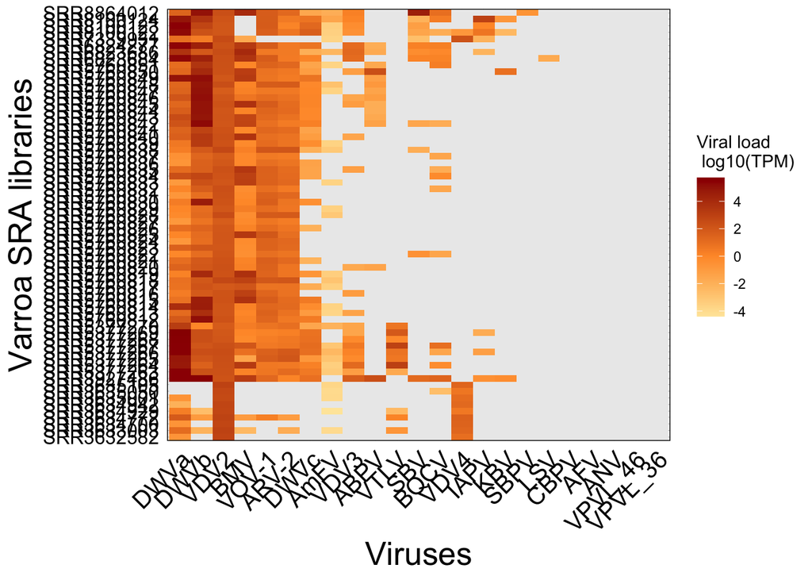

Figure 1. Viral load is diverse across the different varroa libraries. Values are log10 transformed of the reads’ TPM (transcript per millions). Zero values are marked in grey (i.e., none of the reads in this library mapped to this virus). The viruses’ names are abbreviated as described in Table 1. More information on the viruses’, accession numbers, genome length, references and etc. are available in supp table S1. Members of the Iflavirus family are the most prevalent, yet while some viruses are homogenous across libraries (VDV2), others are highly diverse (e.g. DWVa and DWVb).

```r
# (3) heat-map of viruses loads (log10(tpm)) per library
# load the former virus data
load(file = "/Users/nuriteliash/Documents/GitHub/varroa-virus-networks/results/viruses_load.rds")
# plot the viruses abundance in each library
# make a vector of the new viruses order
new_order <- c("DWVa", "VDV1/DWVb", "VDV2", "BMV","VOV_1","ARV_2", "DWVc", "AmFV", "VDV3", "ABPV", "VTLV", "SV", "BQCV","VDV4", "IAPV", "KBV", "SBPV", "LSV","CBPV" ,"AFV", "ANV", "VPVL_46","VPVL_36")

# re-order the viruses, based on viral load and viral abundance (from highest, on the left, to lowest on the right), and change the names of the viruses to match their common name in the literature:
viruses_load_arranged <- viruses_load  %>%
  mutate(description =  factor(description, levels = new_order)) %>%
  arrange(description) %>%
  mutate(across("description", str_replace, "VOV_1", "VOV-1")) %>%
  mutate(across("description", str_replace, "ARV_2", "ARV-2")) %>%
  mutate(across("description", str_replace, "SV", "SBV")) %>%
  mutate(across("description", str_replace, "LSBV", "LSV")) %>%
  mutate(across("description", str_replace, "VDV1/DWVb", "DWVb"))

# lock in factor level order
viruses_load_arranged$description <- factor(viruses_load_arranged$description, levels = viruses_load_arranged$description)

# spread the df
virus_abund <- viruses_load_arranged %>%
    gather("library", "tpm", -description)

virus_abund[, 3] <- (virus_abund[,3]+ 0.000001) # I added 0.000001 to each value, so there will be no zeros
virus_abund[, 3] <- log10(virus_abund[,3]) # tpm in log10 scale
virus_abund <- replace_with_na(virus_abund, replace = list(tpm = -6)) # whenever there is a zero value (-6), I replace with NA, so the cell will appear in gray color.

# now make a heat map
ggplot(data = virus_abund, mapping = aes(x = description,
                                                       y = library,
                                                       fill = tpm)) +
  scale_fill_gradient2(low="#FFFFCC", mid = "#FF9933", high="#990000",  na.value = "grey92") +
  geom_tile() +
  theme_linedraw() +
  xlab(label = "Viruses") +
  ylab(label = "Varroa SRA libraries") +
  labs(fill = "Viral load \n log10(TPM)") +
  theme(axis.text.x = element_text(angle = 45, hjust = 1, size = 15)) +
  theme(axis.text.y = element_text(size = 12)) +
  theme(axis.ticks = element_blank()) +
  theme(axis.title = element_text(size = 20))
```

### Virus correlation matrix

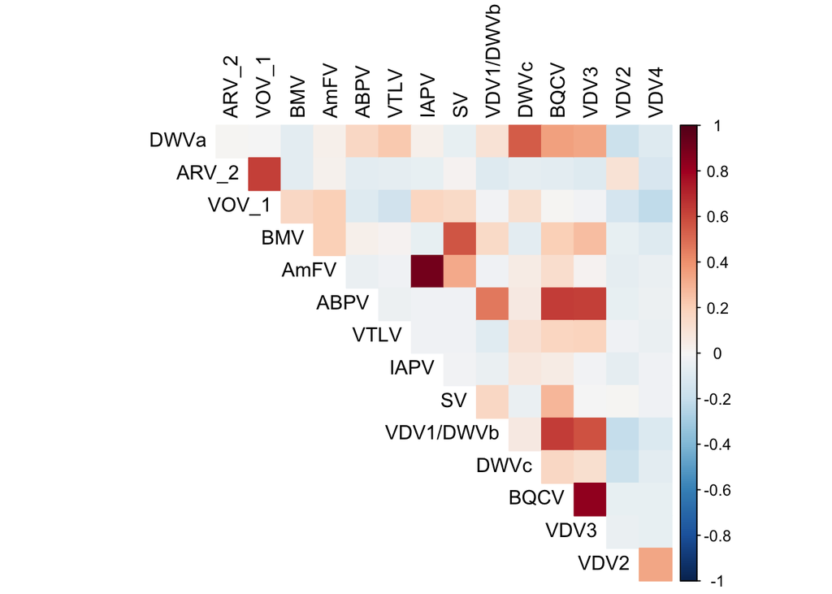

```r
load(file = "/Users/nuriteliash/Documents/GitHub/varroa-virus-networks/results/viruses_load.rds")

# prepare the 'viruses_load' table, with 15 viruses,
# excluding viruses with 'zero tpm': "CBPV", "AFV", "ANV" , "VPVL_46", "VPVL_36", "SBPV", also excluding viruses with low abundance :"KBV", "LSV".  left with 15 viruses
viruses_load_15 <- viruses_load %>%
  filter(description %in% c("DWVa", "ARV_2","VOV_1", "BMV","AmFV","ABPV","VTLV","IAPV","SV","VDV1/DWVb","DWVc","BQCV","VDV3","VDV2","VDV4")) %>%
  column_to_rownames("description") %>%
  transposeBigData() %>%
  rownames_to_column("library") %>%
  #identify and remove the row numbers of the outlierd libraries (found by PCA)
  #filter(!(library %in% c("SRR5109825", "SRR5109827", "SRR533974" , "SRR3927496", "SRR8867385"))) %>%
  column_to_rownames("library")

# make a function to correlate viruses load
corrplot2 <- function(data,
                      method = "pearson",
                      sig.level = 0.05,
                      order = "original",
                      diag = FALSE,
                      type = "upper",
                      tl.srt = 75,
                      number.font = 1,
                      number.cex = 0.5,
                      mar = c(0, 0, 0, 0)) {

  data_incomplete <- data
  data <- data[complete.cases(data), ]
  mat <- cor(data, method = method)
  cor.mtest <- function(mat, method) {
    mat <- as.matrix(mat)
    n <- ncol(mat)
    p.mat <- matrix(NA, n, n)
    diag(p.mat) <- 0
    for (i in 1:(n - 1)) {
      for (j in (i + 1):n) {
        tmp <- cor.test(mat[, i], mat[, j], method = method)
        p.mat[i, j] <- p.mat[j, i] <- tmp$p.value
      }
    }
    colnames(p.mat) <- rownames(p.mat) <- colnames(mat)
    p.mat
  }
  p.mat <- cor.mtest(data, method = method)
  col <- colorRampPalette(c("#053061","#2166ac","#4393c3","#92c5de","#d1e5f0","#f7f7f7","#fddbc7","#f4a582","#d6604d","#b2182b","#67001f"))
  corrplot(mat,
    method = "color", col = col(200),
    mar = mar,
    type = type, order = order,
    tl.col = "black", # replace with "white" to hide the viruses names, as in the plot for the MS.
    # hide correlation coefficients on the diagonal
    diag = diag
  )
}

# plot the correlogram
virusAbundCor_66 <- corrplot2(
  data = viruses_load_15,
  method = "pearson",
  sig.level = 0.05,
  order = "original",
  diag = F,
  type = "upper",
  tl.srt = 75)
```

```r
# save the matrix for future analysis (Mantel)
#saveRDS(virusAbundCor_66, file = "/Users/nuriteliash/Documents/GitHub/varroa-virus-networks/results/virusAbundCor_66.rds")

# and the table of viral load of the 15 viruses in 66 libraries:
#save(viruses_load_15, file = "results/viruses_load_15.rds")
```

## Gene network analysis

We used a network analysis approach to identify groups of genes that share a similar expression pattern across a large set of available varroa transcriptomic data (RNAseq). To construct the gene-network, a weighted gene co-expression analysis was carried out using the WGCNA package in R, following the authors’ tutorial (Langfelder and Horvath 2016; Langfelder and Horvath 2008) . The gene network analysis included 4 main steps: (1) Network construction and module detection; (2) Correlating modules to external information, the varroa viral load; (3) Identifying important genes, ‘hub-genes’; and (4) GO-term enrichment analysis for varroa modules which interact with the viral load.

A gene co-expression network identify genes that interact with one another based on common expression profiles (Barabási and Oltvai 2004). Groups of co-expressed genes that have similar expression patterns across samples are identified using hierarchical clustering and are placed in gene ‘modules’ (Miller, Horvath, and Geschwind 2010). Weighted gene co-expression analysis was conducted using the WGCNA package in R (Langfelder and Horvath 2008).

### (1) Network construction and module detection

Following the steps in WGCNA tutorial: “Automatic, one-step network construction and module detection”

#### Choosing the soft-thresholding power: analysis of network topology

For the varroa Gene network analysis we gonna use the “for_module” file created in the chunk “PCA” of section “Load data and library filtration”. This data frame is the initial input for all the WGCNA, and contains the varroa genes TPM, where columns are genes’ ID and rows are the RNAseq libraries

```r
load(file = "/Users/nuriteliash/Documents/GitHub/varroa-virus-networks/results/for_modules.rds")

# Choose a set of soft-thresholding powers
powers = c(c(1:10), seq(from = 12, to=25, by=2))
# Call the network topology analysis function
sft = pickSoftThreshold(for_modules, powerVector = powers, verbose = 5)
```

```
## pickSoftThreshold: will use block size 4366.
##  pickSoftThreshold: calculating connectivity for given powers...
##    ..working on genes 1 through 4366 of 10247
##    ..working on genes 4367 through 8732 of 10247
##    ..working on genes 8733 through 10247 of 10247
##    Power SFT.R.sq   slope truncated.R.sq mean.k. median.k. max.k.
## 1      1  0.84900  1.9000          0.807  3610.0    3730.0   5270
## 2      2  0.54000  0.6600          0.894  1910.0    1920.0   3460
## 3      3  0.00867 -0.0596          0.507  1200.0    1150.0   2540
## 4      4  0.22700 -0.3920          0.527   826.0     820.0   1970
## 5      5  0.35500 -0.6060          0.599   603.0     603.0   1580
## 6      6  0.42100 -0.7390          0.652   459.0     446.0   1300
## 7      7  0.45200 -0.8360          0.675   359.0     337.0   1080
## 8      8  0.49200 -0.8910          0.695   288.0     257.0    916
## 9      9  0.49900 -0.9460          0.682   236.0     199.0    787
## 10    10  0.51500 -0.9400          0.646   196.0     157.0    684
## 11    12  0.88600 -0.8650          0.973   141.0      99.9    557
## 12    14  0.87200 -1.0800          0.922   106.0      66.2    521
## 13    16  0.87100 -1.2100          0.871    82.4      44.8    491
## 14    18  0.86000 -1.2900          0.824    65.9      31.3    465
## 15    20  0.85000 -1.3200          0.809    53.9      22.2    442
## 16    22  0.84800 -1.3300          0.822    45.1      16.2    422
## 17    24  0.84000 -1.3200          0.840    38.4      11.9    404
```

```r
# Plot the results:
sizeGrWindow(9, 5)
par(mfrow = c(1,2));
cex1 = 0.9;
# Scale-free topology fit index as a function of the soft-thresholding power
plot(sft$fitIndices[,1], -sign(sft$fitIndices[,3])*sft$fitIndices[,2],
     xlab="Soft Threshold (power)",ylab="Scale Free Topology Model Fit,signed R^2",type="n",
     main = paste("Scale independence"));
text(sft$fitIndices[,1], -sign(sft$fitIndices[,3])*sft$fitIndices[,2],
     labels=powers,cex=cex1,col="red");
# this line corresponds to using an R^2 cut-off of h
abline(h=0.80,col="red")
# Mean connectivity as a function of the soft-thresholding power
plot(sft$fitIndices[,1], sft$fitIndices[,5],
     xlab="Soft Threshold (power)",ylab="Mean Connectivity", type="n",
     main = paste("Mean connectivity"))
text(sft$fitIndices[,1], sft$fitIndices[,5], labels=powers, cex=cex1,col="red")
```

#### Constructing the gene network and identifying modules is now a simple function call:

```r
net = blockwiseModules(for_modules, power = 12,
                       TOMType = "unsigned", minModuleSize = 30,
                       reassignThreshold = 0, mergeCutHeight = 0.25, #0.25 means a correlation of 0.75
                       numericLabels = TRUE, pamRespectsDendro = FALSE,
                       #saveTOMs = TRUE,
                       #saveTOMFileBase = "/Users/nuriteliash/Documents/GitHub/varroa-virus-networks/results/Varroa_modulesTOM",
                       verbose = 3)

# To see how many modules were identified and what the module sizes are, one can use table(net$colors).
table(net$colors)
#saveRDS(net, "/Users/nuriteliash/Documents/GitHub/varroa-virus-networks/results/net.rds")
```

Based on the analysis of network topology, for the construction of the network we set our threshold for merging of modules to 0.25, minimum number of 30 genes per module, and the power β of 12. This power is the lowest for which the scale-free topology fit index curve flattens out upon reaching a high value, in this case, when Rsq reaches 0.886 (Fig S2a). We then performed hierarchical clustering of the genes based on topological overlap (sharing of network neighborhood) to identify groups of genes who coexpressed across libraries, these are the network modules (fig S2b).

The hierarchical clustering dendrogram (tree) used for the module identification is returned in net$dendrograms[[1]]; The dendrogram can be displayed together with the color assignment using the following code

```r
net <- readRDS("/Users/nuriteliash/Documents/GitHub/varroa-virus-networks/results/net.rds")

# open a graphics window
sizeGrWindow(12, 9)
# Convert labels to colors for plotting
mergedColors = labels2colors(net$colors)
# Plot the dendrogram and the module colors underneath
plotDendroAndColors(net$dendrograms[[1]], mergedColors[net$blockGenes[[1]]],
                    "Module colors",
                    dendroLabels = FALSE, hang = 0.03,
                    addGuide = TRUE, guideHang = 0.05)
```

Save the module assignment and module eigengene information necessary for subsequent analysis:

```r
moduleLabels = net$colors
moduleColors = labels2colors(net$colors)
MEs = net$MEs;
geneTree = net$dendrograms[[1]];
#save(MEs, moduleLabels, moduleColors, geneTree, file = "/Users/nuriteliash/Documents/GitHub/varroa-virus-networks/results/Varroa_modules_networkConstruction-auto.RData")
```

### (2) Correlating modules to viral load

To test if the varroa modules interact with the different viruses it carries, we correlated the module eigengenes to the viruses’ load (log10TPM). We used Pearson correlation method and adjusted the p-values for multiple comparisons using the Benjamini–Hochberg method to control the false discovery rate (Benjamini and Hochberg 1995) (Fig 2b).

```r
# For correlating varroa modules to viral load, we gonna use the table of 15 viruses saved in chunk "viral correlation", in section "viral correlation matrix", and correlated these to the varroa modules eigengenes found in the previous chunk.

# First we load the two data:
load("/Users/nuriteliash/Documents/GitHub/varroa-virus-networks/results/viruses_load_15.rds")
load(file = "/Users/nuriteliash/Documents/GitHub/varroa-virus-networks/results/Varroa_modules_networkConstruction-auto.RData")

# Define numbers of genes and samples
nGenes = ncol(for_modules);
nSamples = nrow(for_modules)
# Recalculate MEs with color labels
MEs0 = moduleEigengenes(for_modules, moduleColors)$eigengenes
MEs = orderMEs(MEs0)

# correlate the modules eigengenes (MEs) with the viral load (viruses_load_15)
moduleTraitCor = cor(MEs, viruses_load_15, use = "p");
moduleTraitPvalue = corPvalueStudent(moduleTraitCor, nSamples)

### Controlling the false discovery rate: Benjamini–Hochberg procedure ###
# using p.adjust function, for all comparisons, 15 modules and 15 viruses (m=225).

# first make the p-value matrix into a dataframe
moduleTraitPvalue_0 <- as.data.frame(moduleTraitPvalue)

# then "gather" all the p-values, so they will apear in one column
longer_Pvalue <- moduleTraitPvalue_0 %>%
  rownames_to_column("module") %>%
  gather("virus", "pvalue", -module)

# now calculate the p.adjust for each p-value
Padjust <- p.adjust(longer_Pvalue$pvalue, method = "fdr")

# and add the column of adjusted pvalues
Padjust <- add_column(longer_Pvalue, Padjust)

# now spread it back
moduleTraitPadjust <- Padjust %>%
  dplyr::select(-pvalue) %>%
  group_by(virus) %>%
  pivot_wider(names_from = virus, values_from = Padjust)
moduleTraitPadjust <- column_to_rownames(moduleTraitPadjust, "module")

# before correlating, make the two dataframes into "matrices"
moduleTraitCor_66 <- as.matrix(moduleTraitCor)
moduleTraitPadjust_66 <- as.matrix(moduleTraitPadjust)

#  Display correlations and their adjusted p-values
sizeGrWindow(10,6)
textMatrix = paste(signif(moduleTraitCor_66, 2), "\n(",
                   signif(moduleTraitPadjust_66, 1), ")", sep = "");
dim(textMatrix) = dim(moduleTraitCor_66)
par(mar = c(6, 8.5, 3, 3));
# Display the correlation values within a heatmap plot
labeledHeatmap(Matrix = moduleTraitCor_66,
               xLabels = names(viruses_load_15),
               yLabels = names(MEs),
               #xLabelsAngle = 90,
               ySymbols = names(MEs),
               colorLabels = FALSE,
               colors = hcl.colors(n = 50, palette = "RdBu", alpha = NULL, rev = FALSE, fixup = TRUE),
               invertColors = TRUE,
               textMatrix = textMatrix,
               setStdMargins = FALSE,
               cex.text = 0.7,
               zlim = c(-1,1),
               main = paste("Varroa Module-viruses relationships"))

# save the matrices for next analyses
#save(moduleTraitCor_66,moduleTraitPadjust_66, file = "/Users/nuriteliash/Documents/GitHub/varroa-virus-networks/results/moduleTraitCor_66.RData")
```

[output not shown]

### (3) Identifying important genes

The important genes were identified according to their Module membership (Langfelder and Horvath 2008), and their annotation (based on sequence similarity to homologue genes). A gene Module membership expresses its connection to other genes in the module, and therefore, measures the extent to which this gene represents the overall module. The Module membership is calculated by Pearson correlation of the module eigengene and the gene expression. Genes with high Module membership and relevant annotation are likely to play a role in the vector-virus interaction, and are good candidates for later experimental validation.

#### Calculating gene Module-membership (MM)

```r
# names (colors) of the modules
modNames = substring(names(MEs), 3)
# virusNames = substring(names(viruses_load_15), 1)

#make a table of the Module-membership ("MM") of each gene (which is its correlation coefficient, pearson)
geneModuleMembership_66 = as.data.frame(cor(for_modules, MEs, use = "p"));
MMPvalue_66 = as.data.frame(corPvalueStudent(as.matrix(geneModuleMembership_66), nSamples));

### Controlling the false discovery rate: Benjamini–Hochberg procedure ###
# using p.adjust function, for all comparisons, 15 modules and 15 viruses (m=225).

# first make the p-value matrix into a dataframe
MMPvalue_66_0 <- as.data.frame(MMPvalue_66)

# then "gather" all the p-values, so they will appear in one column
longer_Pvalue <- MMPvalue_66_0 %>%
    rownames_to_column("module") %>%
    gather("virus", "pvalue", -module)

# now calculate the p.adjust for each p-value
Padjust <- p.adjust(longer_Pvalue$pvalue, method = "fdr")

# and add the column of adjusted pvalues
Padjust <- add_column(longer_Pvalue, Padjust)

# now spread it back
MMPadjust_66 <- Padjust %>%
    dplyr::select(-pvalue) %>%
    group_by(virus) %>%
    pivot_wider(names_from = virus, values_from = Padjust)
MMPadjust_66 <- column_to_rownames(MMPadjust_66, "module")

#change the name of the columns to start with "MM" then the module name
names(geneModuleMembership_66) = paste("MM", modNames, sep="");
names(MMPadjust_66) = paste("padj.MM", modNames, sep="");
```

#### Identifying genes with high Module-membership in module 10 (the purple module) and adding gene annotations

```r
genePurple = data.frame(
  moduleCol = moduleColors,
  geneModuleMembership_66,
  MMPadjust_66) %>%
  dplyr::select(c(moduleCol, MMpurple, padj.MMpurple)) %>%
  dplyr::filter(moduleCol == "purple") %>%
  mutate(moduleNum = "Module.10") %>%
  rownames_to_column("genes")

# add gene annotation:
# load the annotation file:
annot_varroa <- read_csv("/Users/nuriteliash/Documents/GitHub/varroa-virus-networks/data/annot_varroa.csv", col_names = TRUE, )

# remove the "LOC" from the gene name
annot_varroa$Locus <- str_replace(annot_varroa$Locus, "LOC", '')
# change the col name to "genes", so it will the same as in the "overlap" table
colnames(annot_varroa)[which(names(annot_varroa) == "Locus")] <- "genes"
head(annot_varroa)
```

```
## # A tibble: 6 x 11
##   Name  Accession  Start   Stop Strand GeneID genes `Locus tag` `Protein produc…
##   <chr> <chr>      <dbl>  <dbl> <chr>   <dbl> <chr> <chr>       <chr>
## 1 Un    NW_01921… 3.38e7 3.39e7 -      1.11e8 1112… -           XP_022672900.1
## 2 Un    NW_01921… 3.38e7 3.39e7 -      1.11e8 1112… -           XP_022672902.1
## 3 Un    NW_01921… 3.38e7 3.39e7 -      1.11e8 1112… -           XP_022672903.1
## 4 Un    NW_01921… 3.38e7 3.39e7 -      1.11e8 1112… -           XP_022672904.1
## 5 Un    NW_01921… 3.38e7 3.39e7 -      1.11e8 1112… -           XP_022672905.1
## 6 Un    NW_01921… 3.38e7 3.39e7 -      1.11e8 1112… -           XP_022672908.1
## # … with 2 more variables: Length <dbl>, Protein Name <chr>
```

```r
genesModule.10 <- left_join(annot_varroa, genePurple, by = "genes") %>%
  na.omit() %>%
  dplyr::select("genes", "moduleNum", "MMpurple", "padj.MMpurple", "Accession", "Protein Name") %>%
  dplyr::rename(c(MM = MMpurple, MMpadj = padj.MMpurple))
# there are total of 263 matching annotations, as some of the genes have a few isoforms.

# save the final table of the genes in module 10
write_csv(genesModule.10, "/Users/nuriteliash/Documents/GitHub/varroa-virus-networks/results/genesModule.10.csv")
```

*** NOT INCLUDED *** #### Calculating Gene Significanse (GS)

```r
# save(geneTraitSignificance_66, GSPadjust_66, geneModuleMembership_66, MMPadjust_66, file = "/results/geneTraitANDgeneMM_66.RData")
```

### (4) GO-term enrichment analysis for varroa modules

- Data based on analysis done in [Tehcer et al. (2019)](https://www.nature.com/articles/s42003-019-0606-0) [Maeva Techer github varroa-denovo-genomes project](https://github.com/MaevaTecher/varroa-denovo-genomes/blob/master/data/Positive%20selection/Vdesselected1511.csv)

```r
# load the
annot.vd <- read.csv("/Users/nuriteliash/Documents/GitHub/varroa-virus-networks/data/VdesGOready2.csv")

#Preparing the GO frame
annot.vd2 <- annot.vd %>%
  mutate(evidence = "IEA") %>%
  dplyr::select(go_id = GO.ids, evidence, gene = Gene.id)

head(annot.vd2)
```

```
##        go_id evidence      gene
## 1 GO:0005515      IEA 111242787
## 2 GO:0005576      IEA 111242789
## 3 GO:0008061      IEA 111242789
## 4 GO:0006030      IEA 111242789
## 5 GO:0005887      IEA 111242790
## 6 GO:0004872      IEA 111242790
```

```r
goFrame.vd <-GOFrame(annot.vd2, organism = "Vd")
goAllFrame.vd <-GOAllFrame(goFrame.vd)
gsc.vd <-GeneSetCollection(goAllFrame.vd, setType = GOCollection())

#Preparing the universe
universe.vd <- as.character(unique(annot.vd2$gene)) # there's a wired thing in the GSEAGOHyperGParams function, sometimes its required the universe to be "character".
head(universe.vd)
```

```
## [1] "111242787" "111242789" "111242790" "111242792" "111242797" "111242798"
```

```r
# Preparing the gene set (list of genes in a module)
# change "black" to the name of the desired module, in the first line: [moduleColors=="black"], and in the final "write.csv(file = "GO_term_enrichment_**salmon**BP.csv")
ME <- names(for_modules)[moduleColors=="black"]
ME_df <- data.frame(gene = ME)
genes.vd <- unique(ME_df$gene)
head(genes.vd)
```

```
## [1] "111242800" "111242844" "111242861" "111242884" "111242885" "111242988"
```

```r
params.vd <- GSEAGOHyperGParams(name = "Vd_GO_enrichment",
                                geneSetCollection = gsc.vd,
                                geneIds = genes.vd,
                                universeGeneIds = universe.vd,
                                ontology = "BP", # change with MF, CC to test all
                                pvalueCutoff = 0.05,
                                conditional = F,
                                testDirection = "over")

over.vd <- hyperGTest(params.vd)
over.vd
```

```
## Gene to GO BP  test for over-representation
## 321 GO BP ids tested (81 have p < 0.05)
## Selected gene set size: 39
##     Gene universe size: 5301
##     Annotation package: Based on a GeneSetCollection Object
```

```r
summary(over.vd)
```

```
##        GOBPID       Pvalue  OddsRatio    ExpCount Count Size
## 1  GO:0051127 2.039401e-09 193.308824  0.06621392     5    9
## 2  GO:0051125 4.056980e-09 154.617647  0.07357102     5   10
## 3  GO:0006030 2.083153e-08  30.891047  0.32371251     7   44
## 4  GO:1901071 3.918297e-08  27.855945  0.35314092     7   48
## 5  GO:0006040 4.547088e-08  27.187500  0.36049802     7   49
## 6  GO:0006022 7.987599e-08  24.804348  0.38992643     7   53
## 7  GO:0042752 2.365634e-07  51.441176  0.14714205     5   20
## 8  GO:0045010 3.975217e-07  45.371972  0.16185625     5   22
## 9  GO:0030838 7.892126e-07  38.544118  0.18392756     5   25
## 10 GO:0007623 2.881059e-06  28.513072  0.23542728     5   32
## 11 GO:0030833 3.938483e-06  26.536511  0.25014148     5   34
## 12 GO:0030041 4.570311e-06  25.647059  0.25749859     5   35
## 13 GO:0008064 5.279059e-06  24.814991  0.26485569     5   36
## 14 GO:0030832 5.279059e-06  24.814991  0.26485569     5   36
```

[output cut: 149 more lines]

```r
GO_enrich.vd <- as.data.frame(summary(over.vd)) %>%
  arrange(Pvalue)

# write.csv(GO_enrich.vd, file = "/Users/nuriteliash/Documents/GitHub/varroa-virus-networks/results/GO_term_black.csv")
```

## Correlating virus interaction and virus-varroa interactions

To test if we can predict the virus-varroa interaction given the virus abundance, we used Mantel-test for correlation between two distance-matrices (Mantel 1967).

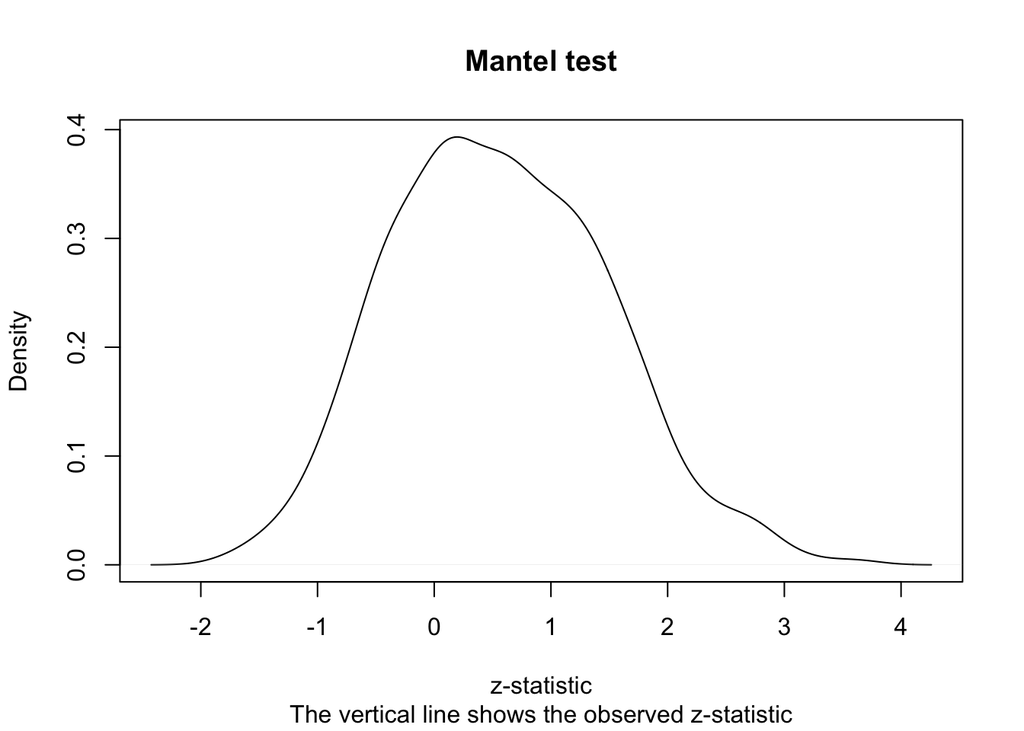

```
## $z.stat
## [1] 6.276091
##
## $p
## [1] 0.001
##
## $alternative
## [1] "two.sided"
```

```r
# load the two matrices:
# the module–trait association matrix:
load(file = "/Users/nuriteliash/Documents/GitHub/varroa-virus-networks/results/moduleTraitCor_66.RData")

# and the viral abundance correlogram:
virusAbundCor_66 <- readRDS(file = "/Users/nuriteliash/Documents/GitHub/varroa-virus-networks/results/virusAbundCor_66.rds")
virusAbundCor_66 <- virusAbundCor_66$corr

# make correlation matrix of the "moduleTraitCor":
corModulTrait_66 <- cor(moduleTraitCor_66)

# (1) Mantel test using "ape" library:
mantel.test(corModulTrait_66, virusAbundCor_66, graph = TRUE,
            main = "Mantel test",
            xlab = "z-statistic", ylab = "Density",
            sub = "The vertical line shows the observed z-statistic")
```

```r
# (2) Mantel test using "vegan" library:
mantel(corModulTrait_66, virusAbundCor_66, method="pearson", permutations=1000)
```

```
##
## Mantel statistic based on Pearson's product-moment correlation
##
## Call:
## mantel(xdis = corModulTrait_66, ydis = virusAbundCor_66, method = "pearson",      permutations = 1000)
##
## Mantel statistic r: 0.6044
##       Significance: 0.000999
##
## Upper quantiles of permutations (null model):
##   90%   95% 97.5%   99%
## 0.135 0.170 0.205 0.234
## Permutation: free
## Number of permutations: 1000
```

```r
#plot the correlation
sizeGrWindow(9, 5)
verboseScatterplot(x = corModulTrait_66, y = virusAbundCor_66, main = "Correlation between Fig 2a, \n virus-virus interaction; and Fig 2b, \n varroa-virus interaction", xlab = "Correlation of viral interaction \nwith varroa modules", ylab = "Correlation of viral abundance", abline = T, abline.color = "black", bg = "black", cex.lab = 1.2, cex.main = 1, cex.axis = 1)
```

We found a significant positive correlation between the two distance matrices (Mantel-test for correlation between two distance-matrices (Mantel 1967), Mantel statistic r = 0.604, p = 0.001) (Fig 2c). Meaning, given viruses’ interaction we can predict how these viruses will interact with the vector’s module.